# IODS course project

# 3 Logistic regression

## 3.1. Students aclohol dataset

Read the alcohol consumption data from following location [here](https://archive.ics.uci.edu/ml/datasets/STUDENT+ALCOHOL+CONSUMPTION)

Citation: P. Cortez and A. Silva. Using Data Mining to Predict Secondary School Student Performance. In A. Brito and J. Teixeira Eds., Proceedings of 5th FUture BUsiness TEChnology Conference (FUBUTEC 2008) pp. 5-12, Porto, Portugal, April, 2008, EUROSIS, ISBN 978-9077381-39-7.

Changes in the dataset:

*The variables not used for joining the two data have been combined by averaging (including the grade variables)* ‘alc_use’ is the average of ‘Dalc’ and ‘Walc’ *‘high_use’ is TRUE if ‘alc_use’ is higher than 2 and FALSE otherwise

## 3.2. Read the file

The data are read using the following command:

```r
##Load required libraries
library(GGally)
library(ggplot2)
library(dplyr)
library(reshape2)
#read the data in the file produced at the end of the assignment
alc<- read.table("http://s3.amazonaws.com/assets.datacamp.com/production/course_2218/datasets/alc.txt", sep=",",header=TRUE)


dim(alc)
```

```
## [1] 382  35
```

```r
str(alc)
```

```
## 'data.frame':    382 obs. of  35 variables:
##  $ school    : Factor w/ 2 levels "GP","MS": 1 1 1 1 1 1 1 1 1 1 ...
##  $ sex       : Factor w/ 2 levels "F","M": 1 1 1 1 1 2 2 1 2 2 ...
##  $ age       : int  18 17 15 15 16 16 16 17 15 15 ...
##  $ address   : Factor w/ 2 levels "R","U": 2 2 2 2 2 2 2 2 2 2 ...
##  $ famsize   : Factor w/ 2 levels "GT3","LE3": 1 1 2 1 1 2 2 1 2 1 ...
##  $ Pstatus   : Factor w/ 2 levels "A","T": 1 2 2 2 2 2 2 1 1 2 ...
##  $ Medu      : int  4 1 1 4 3 4 2 4 3 3 ...
##  $ Fedu      : int  4 1 1 2 3 3 2 4 2 4 ...
##  $ Mjob      : Factor w/ 5 levels "at_home","health",..: 1 1 1 2 3 4 3 3 4 3 ...
##  $ Fjob      : Factor w/ 5 levels "at_home","health",..: 5 3 3 4 3 3 3 5 3 3 ...
##  $ reason    : Factor w/ 4 levels "course","home",..: 1 1 3 2 2 4 2 2 2 2 ...
##  $ nursery   : Factor w/ 2 levels "no","yes": 2 1 2 2 2 2 2 2 2 2 ...
##  $ internet  : Factor w/ 2 levels "no","yes": 1 2 2 2 1 2 2 1 2 2 ...
##  $ guardian  : Factor w/ 3 levels "father","mother",..: 2 1 2 2 1 2 2 2 2 2 ...
```

[output cut: 21 more lines]

```r
head(alc)
```

```
##   school sex age address famsize Pstatus Medu Fedu     Mjob     Fjob
## 1     GP   F  18       U     GT3       A    4    4  at_home  teacher
## 2     GP   F  17       U     GT3       T    1    1  at_home    other
## 3     GP   F  15       U     LE3       T    1    1  at_home    other
## 4     GP   F  15       U     GT3       T    4    2   health services
## 5     GP   F  16       U     GT3       T    3    3    other    other
## 6     GP   M  16       U     LE3       T    4    3 services    other
##       reason nursery internet guardian traveltime studytime failures
## 1     course     yes       no   mother          2         2        0
## 2     course      no      yes   father          1         2        0
## 3      other     yes      yes   mother          1         2        3
## 4       home     yes      yes   mother          1         3        0
## 5       home     yes       no   father          1         2        0
## 6 reputation     yes      yes   mother          1         2        0
##   schoolsup famsup paid activities higher romantic famrel freetime goout
## 1       yes     no   no         no    yes       no      4        3     4
## 2        no    yes   no         no    yes       no      5        3     3
## 3       yes     no  yes         no    yes       no      4        3     2
## 4        no    yes  yes        yes    yes      yes      3        2     2
## 5        no    yes  yes         no    yes       no      4        3     2
## 6        no    yes  yes        yes    yes       no      5        4     2
##   Dalc Walc health absences G1 G2 G3 alc_use high_use
## 1    1    1      3        6  5  6  6     1.0    FALSE
## 2    1    1      3        4  5  5  6     1.0    FALSE
## 3    2    3      3       10  7  8 10     2.5     TRUE
## 4    1    1      5        2 15 14 15     1.0    FALSE
## 5    1    2      5        4  6 10 10     1.5    FALSE
## 6    1    2      5       10 15 15 15     1.5    FALSE
```

```r
colnames(alc)
```

```
##  [1] "school"     "sex"        "age"        "address"    "famsize"
##  [6] "Pstatus"    "Medu"       "Fedu"       "Mjob"       "Fjob"
## [11] "reason"     "nursery"    "internet"   "guardian"   "traveltime"
## [16] "studytime"  "failures"   "schoolsup"  "famsup"     "paid"
## [21] "activities" "higher"     "romantic"   "famrel"     "freetime"
## [26] "goout"      "Dalc"       "Walc"       "health"     "absences"
## [31] "G1"         "G2"         "G3"         "alc_use"    "high_use"
```

## 3.3. Choice of depending variables, which affect alcohol consumption

The purpose of this analysis is to study the relationships between high/low alcohol consumption and some of the other variables in the data.

There are numerous parameters which are affected by the alcohol consumption. To analyse and hypothyze different relationships, one can easily study following parameters.

1. Sex - student’s sex (binary: ‘F’ - female or ‘M’ - male): Usually a big differentiating factor.
2. Age - student’s age (numeric: from 15 to 22) : Age plays crucial role in analyzing the alcohol consumpution (what age we should be careful)
3. Health - current health status (numeric: from 1 - very bad to 5 - very good) : Easily the most related parameter depending upon the consumption
4. Absences - number of school absences (numeric: from 0 to 93) : How are studies affected by the alcohol consumption

## 3.4 Graphical representation of distributions of the relationships between alcohol consumptions and the variables.

### Box plots

box plot or boxplot is a convenient way of graphically depicting groups of numerical data through their quartiles. Box represents area of the first quartile to the third quartile. Line shows median and “whiskers” above and below the box show the locations of the minimum and maximum. Points plotted outside are outliers.

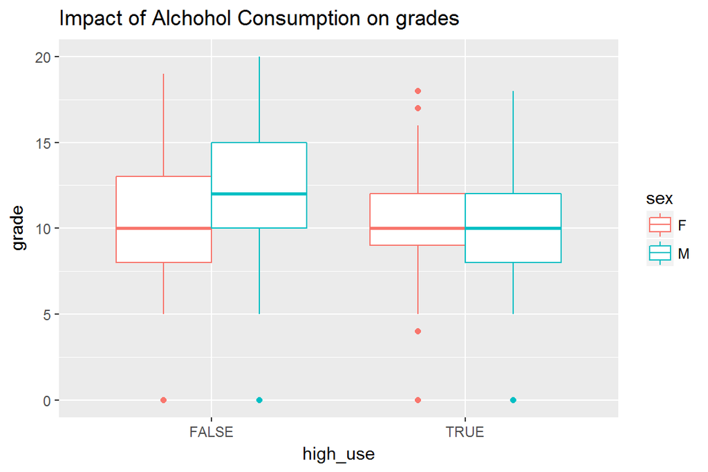

```r
g1 <- ggplot(alc, aes(x = high_use, y = G3, col=sex)) + ggtitle("Impact of Alchohol Consumption on grades")
g1 + geom_boxplot() + ylab("grade")
```

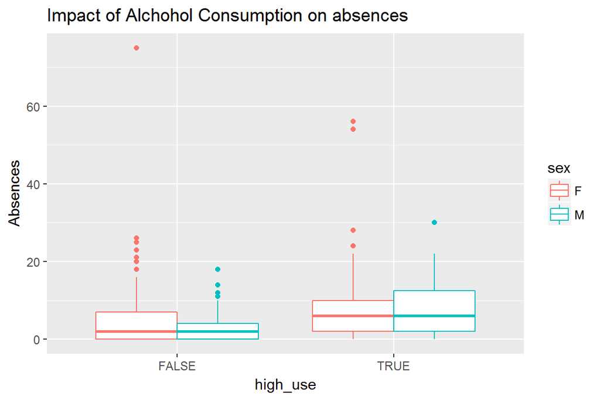

```r
g2 <- ggplot(alc, aes(x = high_use, y = absences, col=sex)) + ggtitle("Impact of Alchohol Consumption on absences")
g2 + geom_boxplot() + ylab("Absences")
```

[figure not shown]

```r
g3 <- ggplot(alc, aes(x = high_use, y = health, col=sex)) + ggtitle("Impact of Alchohol Consumption on Student grades and Health")
g3 + geom_boxplot() + ylab("Health") + scale_y_reverse()
```

Appearantly males health does not suffer much with high consumption but females are more sensitive with higher alcohol consumption

[figure not shown]

```r
g4 <- ggplot(alc, aes(x = high_use, y = age, col=sex)) + ggtitle("Student absences by alcohol consumption and age")
g4 + geom_boxplot() + ylab("Age")
```

While it is not the entire set of variables. These factors are indicative of the impact of alchol consumption on students.

### Bar plots

Bar plots are one of the most commonly used kind of data visualization. They are used to display numeric values (on the y-axis), for different categories (on the x-axis).

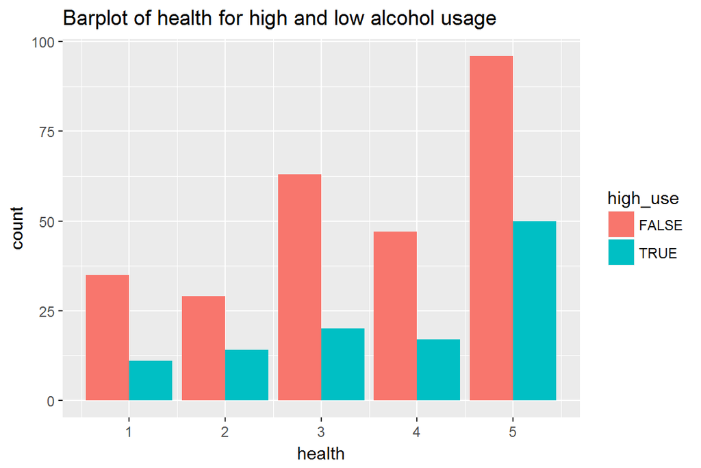

```r
bp <- ggplot(alc, aes(health, fill=high_use)) + geom_bar(position="dodge") +
  ggtitle("Barplot of health for high and low alcohol usage")
bp
```

[figure not shown]

```r
bp2 <- ggplot(alc, aes(sex, fill=high_use)) + geom_bar(position="dodge") +
  ggtitle("Barplot of free time counts for high and low alcohol usage")
bp2
```

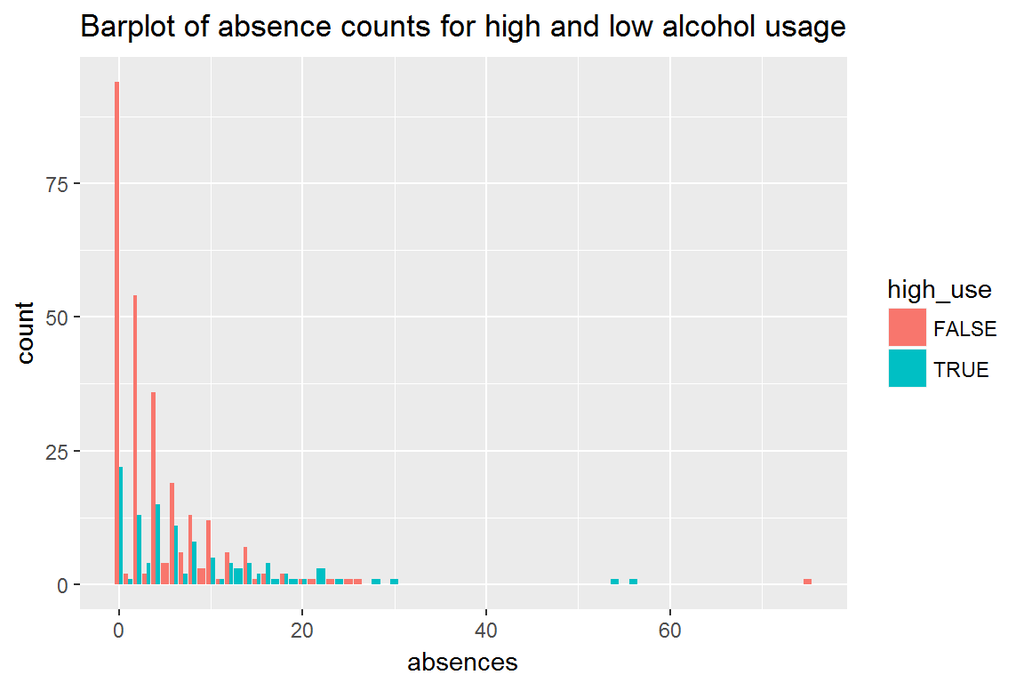

```r
bp3 <- ggplot(alc, aes(absences, fill=high_use)) + geom_bar(position="dodge") +
  ggtitle("Barplot of absence counts for high and low alcohol usage")
bp3
```

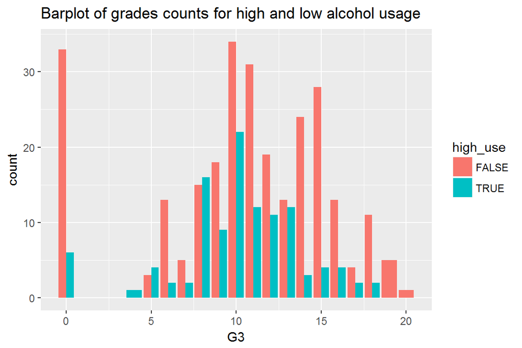

```r
bp4 <- ggplot(alc, aes(G3, fill=high_use)) + geom_bar(position="dodge") +
  ggtitle("Barplot of grades counts for high and low alcohol usage")
bp4
```

Barplots confirm the findings in the box plots in different way.

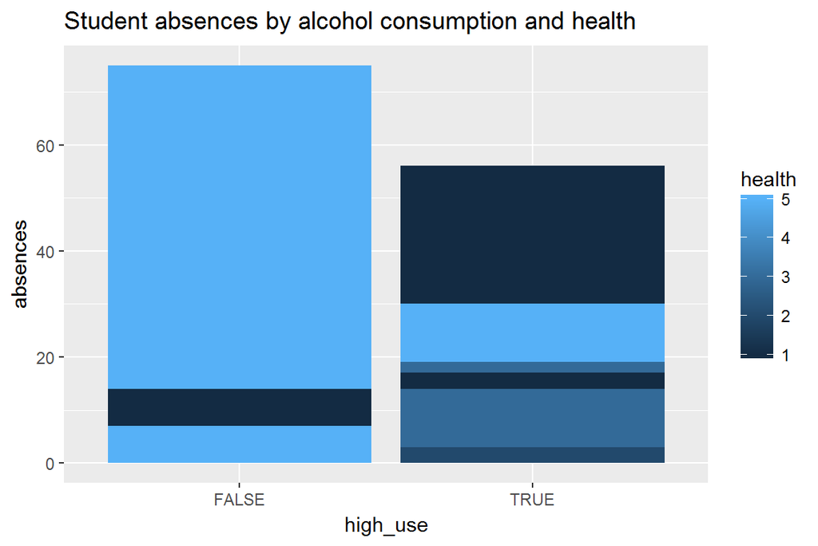

```r
b3 <- ggplot(alc, aes(x=high_use, y=absences, fill=health)) +
  geom_bar(stat="identity", position=position_dodge()) +
  ggtitle("Student absences by alcohol consumption and health")
# draw the plot
b3
```

### Cross-tabulations (contingency table)

Cross tabulations are type of tables in a matrix format that displays the (multivariate) frequency distribution of the variables. They provide a basic picture of the interrelation between two variables and can help find interactions between them.

```r
library(descr)
CrossTable(alc$health,alc$high_use, prop.t=TRUE, prop.r=TRUE, prop.c=TRUE)
```

```
##    Cell Contents
## |-------------------------|
## |                       N |
## | Chi-square contribution |
## |           N / Row Total |
## |           N / Col Total |
## |         N / Table Total |
## |-------------------------|
##
## ===================================
##               alc$high_use
## alc$health    FALSE    TRUE   Total
## -----------------------------------
## 1                35      11      46
##               0.190   0.459
##               0.761   0.239   0.120
##               0.130   0.098
##               0.092   0.029
## -----------------------------------
## 2                29      14      43
##               0.064   0.154
##               0.674   0.326   0.113
##               0.107   0.125
##               0.076   0.037
## -----------------------------------
## 3                63      20      83
##               0.320   0.772
##               0.759   0.241   0.217
##               0.233   0.179
##               0.165   0.052
## -----------------------------------
## 4                47      17      64
##               0.069   0.166
##               0.734   0.266   0.168
##               0.174   0.152
##               0.123   0.045
## -----------------------------------
## 5                96      50     146
##               0.501   1.209
##               0.658   0.342   0.382
##               0.356   0.446
##               0.251   0.131
## -----------------------------------
## Total           270     112     382
##               0.707   0.293
## ===================================
```

```r
CrossTable(alc$sex,alc$high_use, prop.t=TRUE, prop.r=TRUE, prop.c=TRUE)
```

```
##    Cell Contents
## |-------------------------|
## |                       N |
## | Chi-square contribution |
## |           N / Row Total |
## |           N / Col Total |
## |         N / Table Total |
## |-------------------------|
##
## ================================
##            alc$high_use
## alc$sex    FALSE    TRUE   Total
## --------------------------------
## F            157      41     198
##            2.078   5.009
##            0.793   0.207   0.518
##            0.581   0.366
##            0.411   0.107
## --------------------------------
## M            113      71     184
##            2.236   5.390
##            0.614   0.386   0.482
##            0.419   0.634
##            0.296   0.186
## --------------------------------
## Total        270     112     382
##            0.707   0.293
## ================================
```

## 3.5 Logistic regression

Model the variable high_use as a function of chosen dependent variables using logistic regression.

Logistic regression is a method for fitting a regression curve, y = f(x), when y consists of proportions or probabilities, or binary coded (0,1–failure, success) data. When the response is a binary (dichotomous) variable, and x is numeric, logistic regression fits a logistic curve to the relationship between x and y.

We define the students health as a factorial variable (it takes values 1-5). The model and results (summary and coefficients) are given using following functions:

```r
alc$health <- factor(alc$health)
m <- glm(high_use ~ G3 + absences+sex+health, data = alc, family = "binomial")
summary(m)
```

```
##
## Call:
## glm(formula = high_use ~ G3 + absences + sex + health, family = "binomial",
##     data = alc)
##
## Deviance Residuals:
##     Min       1Q   Median       3Q      Max
## -2.8620  -0.8454  -0.6204   1.0572   2.0505
##
## Coefficients:
##             Estimate Std. Error z value Pr(>|z|)
## (Intercept) -1.68344    0.49385  -3.409 0.000652 ***
## G3          -0.03396    0.02591  -1.311 0.189930
## absences     0.07652    0.01854   4.128 3.66e-05 ***
## sexM         1.01459    0.24875   4.079 4.53e-05 ***
## health2      0.36768    0.50514   0.728 0.466686
## health3     -0.11382    0.46137  -0.247 0.805146
## health4      0.19310    0.47462   0.407 0.684118
## health5      0.32903    0.41962   0.784 0.432968
## ---
## Signif. codes:  0 '***' 0.001 '**' 0.01 '*' 0.05 '.' 0.1 ' ' 1
##
## (Dispersion parameter for binomial family taken to be 1)
##
##     Null deviance: 462.21  on 381  degrees of freedom
## Residual deviance: 421.53  on 374  degrees of freedom
## AIC: 437.53
##
## Number of Fisher Scoring iterations: 4
```

```r
coef(m)
```

```
## (Intercept)          G3    absences        sexM     health2     health3
## -1.68343883 -0.03395765  0.07651849  1.01458713  0.36768133 -0.11381629
##     health4     health5
##  0.19310111  0.32903488
```

```r
confint(m)
```

```
##                   2.5 %      97.5 %
## (Intercept) -2.69205669 -0.74729058
## G3          -0.08465022  0.01723061
## absences     0.04227944  0.11462062
## sexM         0.53341598  1.51054655
## health2     -0.61775150  1.37599976
## health3     -1.00690619  0.81490637
## health4     -0.72685195  1.14700931
## health5     -0.47001929  1.18784390
```

```r
confint.default(m)
```

```
##                   2.5 %     97.5 %
## (Intercept) -2.65136084 -0.7155168
## G3          -0.08473311  0.0168178
## absences     0.04018536  0.1128516
## sexM         0.52704638  1.5021279
## health2     -0.62237191  1.3577346
## health3     -1.01808292  0.7904503
## health4     -0.73714564  1.1233479
## health5     -0.49340847  1.1514782
```

## Link to GitHub Project

https://github.com/potdarswapnil/IODS-project

# 4 Clustering and classification

## 4.1. Boston dataset from MASS package

```r
#Load the Rquired (usual) libraries
library(MASS)
```

```r
library(reshape2)
library(ggplot2)
library(GGally)
library(dplyr)
library(corrplot)
library(tidyverse)
#load the Boston Data
data("Boston")
```

## 4.2. Boston Dataset

Load Boston data from the MASS package in R. The data is described in R documentation [here](https://stat.ethz.ch/R-manual/R-devel/library/MASS/html/Boston.html). This is related to real estate details from Boston suburban area.

- 506 observations of 14 different parameters.
- It contains following columns **crim : per capita crime rate by town.** zn: proportion of residential land zoned for lots over 25,000 sq.ft. **indus: proportion of non-retail business acres per town.** chas: Charles River dummy variable (= 1 if tract bounds river; 0 otherwise). **nox: nitrogen oxides concentration (parts per 10 million).** rm: average number of rooms per dwelling. **age:proportion of owner-occupied units built prior to 1940.** dis:weighted mean of distances to five Boston employment centres. **rad:index of accessibility to radial highways.** tax:full-value property-tax rate per $10,000. **ptratio: pupil-teacher ratio by town.** black: 1000(Bk - 0.63)^2 where Bk is the proportion of blacks by town. **lstat: lower status of the population (percent).** medv: median value of owner-occupied homes in $1000s.

We will focus on the Crime rate and look at the data available.

```r
str(Boston)
```

```
## 'data.frame':    506 obs. of  14 variables:
##  $ crim   : num  0.00632 0.02731 0.02729 0.03237 0.06905 ...
##  $ zn     : num  18 0 0 0 0 0 12.5 12.5 12.5 12.5 ...
##  $ indus  : num  2.31 7.07 7.07 2.18 2.18 2.18 7.87 7.87 7.87 7.87 ...
##  $ chas   : int  0 0 0 0 0 0 0 0 0 0 ...
##  $ nox    : num  0.538 0.469 0.469 0.458 0.458 0.458 0.524 0.524 0.524 0.524 ...
##  $ rm     : num  6.58 6.42 7.18 7 7.15 ...
##  $ age    : num  65.2 78.9 61.1 45.8 54.2 58.7 66.6 96.1 100 85.9 ...
##  $ dis    : num  4.09 4.97 4.97 6.06 6.06 ...
##  $ rad    : int  1 2 2 3 3 3 5 5 5 5 ...
##  $ tax    : num  296 242 242 222 222 222 311 311 311 311 ...
##  $ ptratio: num  15.3 17.8 17.8 18.7 18.7 18.7 15.2 15.2 15.2 15.2 ...
##  $ black  : num  397 397 393 395 397 ...
##  $ lstat  : num  4.98 9.14 4.03 2.94 5.33 ...
##  $ medv   : num  24 21.6 34.7 33.4 36.2 28.7 22.9 27.1 16.5 18.9 ...
```

```r
summary(Boston)
```

```
##       crim                zn             indus            chas
##  Min.   : 0.00632   Min.   :  0.00   Min.   : 0.46   Min.   :0.00000
##  1st Qu.: 0.08204   1st Qu.:  0.00   1st Qu.: 5.19   1st Qu.:0.00000
##  Median : 0.25651   Median :  0.00   Median : 9.69   Median :0.00000
##  Mean   : 3.61352   Mean   : 11.36   Mean   :11.14   Mean   :0.06917
##  3rd Qu.: 3.67708   3rd Qu.: 12.50   3rd Qu.:18.10   3rd Qu.:0.00000
##  Max.   :88.97620   Max.   :100.00   Max.   :27.74   Max.   :1.00000
##       nox               rm             age              dis
##  Min.   :0.3850   Min.   :3.561   Min.   :  2.90   Min.   : 1.130
##  1st Qu.:0.4490   1st Qu.:5.886   1st Qu.: 45.02   1st Qu.: 2.100
##  Median :0.5380   Median :6.208   Median : 77.50   Median : 3.207
##  Mean   :0.5547   Mean   :6.285   Mean   : 68.57   Mean   : 3.795
##  3rd Qu.:0.6240   3rd Qu.:6.623   3rd Qu.: 94.08   3rd Qu.: 5.188
##  Max.   :0.8710   Max.   :8.780   Max.   :100.00   Max.   :12.127
##       rad              tax           ptratio          black
##  Min.   : 1.000   Min.   :187.0   Min.   :12.60   Min.   :  0.32
##  1st Qu.: 4.000   1st Qu.:279.0   1st Qu.:17.40   1st Qu.:375.38
##  Median : 5.000   Median :330.0   Median :19.05   Median :391.44
##  Mean   : 9.549   Mean   :408.2   Mean   :18.46   Mean   :356.67
##  3rd Qu.:24.000   3rd Qu.:666.0   3rd Qu.:20.20   3rd Qu.:396.23
##  Max.   :24.000   Max.   :711.0   Max.   :22.00   Max.   :396.90
##      lstat            medv
##  Min.   : 1.73   Min.   : 5.00
##  1st Qu.: 6.95   1st Qu.:17.02
##  Median :11.36   Median :21.20
##  Mean   :12.65   Mean   :22.53
##  3rd Qu.:16.95   3rd Qu.:25.00
##  Max.   :37.97   Max.   :50.00
```

```r
glimpse(Boston)
```

```
## Observations: 506
## Variables: 14
## $ crim    <dbl> 0.00632, 0.02731, 0.02729, 0.03237, 0.06905, 0.02985, ...
## $ zn      <dbl> 18.0, 0.0, 0.0, 0.0, 0.0, 0.0, 12.5, 12.5, 12.5, 12.5,...
## $ indus   <dbl> 2.31, 7.07, 7.07, 2.18, 2.18, 2.18, 7.87, 7.87, 7.87, ...
## $ chas    <int> 0, 0, 0, 0, 0, 0, 0, 0, 0, 0, 0, 0, 0, 0, 0, 0, 0, 0, ...
## $ nox     <dbl> 0.538, 0.469, 0.469, 0.458, 0.458, 0.458, 0.524, 0.524...
## $ rm      <dbl> 6.575, 6.421, 7.185, 6.998, 7.147, 6.430, 6.012, 6.172...
## $ age     <dbl> 65.2, 78.9, 61.1, 45.8, 54.2, 58.7, 66.6, 96.1, 100.0,...
## $ dis     <dbl> 4.0900, 4.9671, 4.9671, 6.0622, 6.0622, 6.0622, 5.5605...
## $ rad     <int> 1, 2, 2, 3, 3, 3, 5, 5, 5, 5, 5, 5, 5, 4, 4, 4, 4, 4, ...
## $ tax     <dbl> 296, 242, 242, 222, 222, 222, 311, 311, 311, 311, 311,...
## $ ptratio <dbl> 15.3, 17.8, 17.8, 18.7, 18.7, 18.7, 15.2, 15.2, 15.2, ...
## $ black   <dbl> 396.90, 396.90, 392.83, 394.63, 396.90, 394.12, 395.60...
## $ lstat   <dbl> 4.98, 9.14, 4.03, 2.94, 5.33, 5.21, 12.43, 19.15, 29.9...
## $ medv    <dbl> 24.0, 21.6, 34.7, 33.4, 36.2, 28.7, 22.9, 27.1, 16.5, ...
```